# Aside

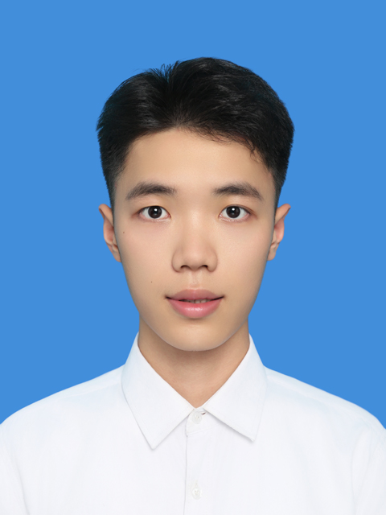

## 联系信息

- 19880838040
- residualsun1@gmail.com
- github.com/residualsun1

## 技能及工具

1. VideCoding 重度爱好者，热衷结合 Claude、Codex 与 Gemini 等 AI 工具进行开发
2. 使用 Google 文档进行协作管理，NotebookLM 进行知识管理学习，Figma 进行产品设计

# Main

## 教育经历

### 中央民族大学

民族学与社会学学院，民族学硕士

北京

2025.09 - 2028.07

### 广州大学

公共管理学院，社会学学士

广州

2021.09 - 2025.07

## 项目经历

### SPARK AI 休闲黑客松（LLM 赛道）

「TimeGambler 时间赌徒」项目产品设计师

北京

2026.01.26 - 2026.02.01

与队友开发「[TimeGambler 时间赌徒](https://github.com/0x-IHRR/ADHD_BlockChain)」Dapp，并在由 LXDAO 与 SpoonOS、Kite AI、OGBC × ScalingX 协作主办的 PARK AI 休闲黑客松的中获得亚军（LLM 赛道）。

本人在项目中结合 VibeCoding 参与了 AI Agent 接入的开发过程，主要负责提出产品 UI 界面优化建议与理念设计，并在评比中对产品进行路演宣讲。具体可见项目[文档演示](https://docs.google.com/presentation/d/1QCIWXFFyP1AbcWcQoHnqobuoJX5F8xQzZZQMCTW4ww4/edit?slide=id.p13#slide=id.p13)与[宣讲文稿](https://docs.google.com/document/d/1ITsJK4--ANd8AlsmNJzBPtb3qo5AcGYLiAPJo77uGy8/edit?tab=t.0)。

### 数据分析

掌握基础数据分析技能，主要使用 R 语言与 Amos

广州

2023 - 2024

**R 语言**：基于广州大学社会学 2020 级本科生定量研究方法课程作业项目为基础进行修改和完善的数据分析笔记。  
具体可见：https://residualsun1.github.io/deploy/

**Amos**：基于 Amos 软件进行基础且完整的结构方程模型数据分析过程。  
具体可见：https://residualsun1.github.io/Amos_sample/

## 实习经历

### 湛江市黑石屿旅游文化发展有限公司

西埠村

湛江

2023.12.11 - 2024.04.21

**1、田野调查与记录**：在硇洲岛西埠村开展为期四个月的田野调查，致力于村庄“流动的神明”的仪式**追踪与记录**，参与民宿返乡青年团队“可持续渔村探索”项目阶段性成果《西埠村人文化生计手册》民俗文化部分的**撰写工作**，并形成**52**篇田野随笔。

**2、活动策划及执行**：参与黑石屿团队**社区活动策划**，拉近在地团队与社区居民关系，先后参与**策划、组织与执行**西埠村神明故事会、村庄理发敬老日活动、西埠村海洋文化座谈会以及黑石屿儿童社参观海洋大学的活动。活动产出回顾成果如下：黑石屿公众号文章[《哇～原来渔村的神明吃肉也是要加盐的～》](https://mp.weixin.qq.com/s/kwcrF2aThDb4fVgPISu07A)、[《海岛文化座谈：和岛民渔民一起聊聊神明》](https://mp.weixin.qq.com/s/4N3FGGITosLDWC_w9nt6Dw)和[《和渔民一起逛大学，从海洋到博物馆》](https://mp.weixin.qq.com/s/pyqwavIoSTsi8u-k78e6bg)。

**3、寻访与海洋生物保护宣传**：在西埠村开展渔民渔业生计调查工作及海洋生物保护**宣传活动**，与当地渔民一同劳作，了解村庄渔民作业方式与生计状况，同时与团队伙伴开展“巡鲎行动”，带领社区儿童救助被渔网误捕的鲎。

## 专业培训

### “万企兴万村”口述故事采写

广州大学乡村振兴研究院口述故事撰写员

广州

2022.07.03 - 2023.06.14

走访碧桂园佛山顺德总部，线上访谈碧桂园“万企兴万村”项目受帮扶对象，并根据访谈文本撰写口述故事《我们与“心愿100”：苦尽必是甘来处》，故事评审获特等奖。

### 2024年中国关键生态系统区域社区保护地研讨会

硇洲岛西埠村渔业社区在地实践经验分享人

南宁

2024.04.28 - 2024.04.30

分享主题：《社区保护如何激发社区能动性》

分享概要：激发能动性需要明确社区居民的生计和社区保护之间的利益相关点。首先需要学会像“土著”一样思考，感受当地人眼中珍贵的事物；其次协助当地居民建立兴趣团队，增强集体关系，还可以因地制宜发展产业，帮助当地人谋求利益。在利益之外，还需要发展与当地领头人的关系，借助更强的力量凝聚社区成员，以开展进一步的保护行动。

### 海洋命运共同体与海洋发展国家级高级研修班

研修班学习员

福建

2023.07.02 - 2023.07.09

### 2023年第三届全国大学生人类学研训营暨之江青年学者人类学理论与方法研训营

人类学理论与方法研训营营员

杭州

2023.09.25 - 2023.09.28

基于在硇洲岛开展的社区活动及思考代表小组进行结营汇报，获优秀营员。

## 荣誉奖项

### 浙江大学

人类学研究所

杭州

2023

- 第三届全国大学生人类学研训营暨之江青年学者人类学理论与方法研训营优秀营员

### 广州大学

公共管理学院

广州

2021 - 2023

- 国际人才英语初级考试（良）
- 全国计算机一级考试
- 全国大学英语四级（573）
- 全国大学英语六级（508）
- 普通话水平测试二乙
- 广州大学第十八届“挑战杯”大学生课外学术科技作品竞赛三等奖
- “万企兴万村口述故事”作品特等奖
- 2021-2022学年本科生三等奖学金
- 2022-2023学年本科生三等奖学金